# Re-Analysis of Other Published Data

Dave Bridges

September 6, 2015

This script is for the re-analysis of previously published data from other groups. This is often for presentations wherein the data was presented as a table or something and we want to draw attention to a particular aspect. This script was most recently run on Wed Mar 17 16:18:17 2021.

# Ebbeling et al JAMA 2012 Paper

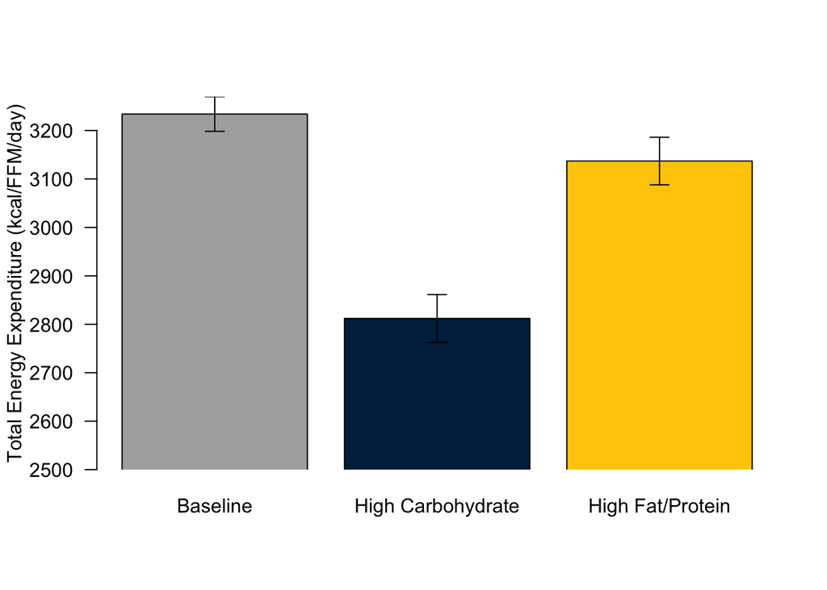

Effect of Maintenance Diet on Energy Expenditure After Weight Loss

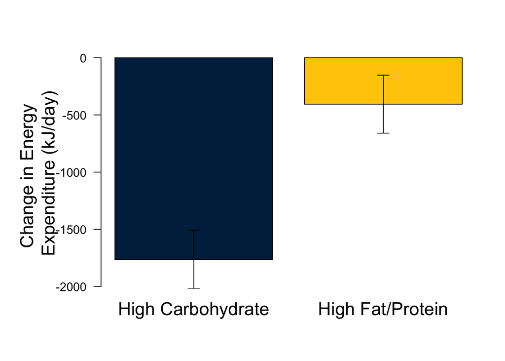

# Bray et al Overfeeding Study

In Bray et al. (2012), subjects were overfed for 8 weeks with equal calories of low, normal (not included here) and high protein diet. Total energy expenditure is taken from the Table in this paper.

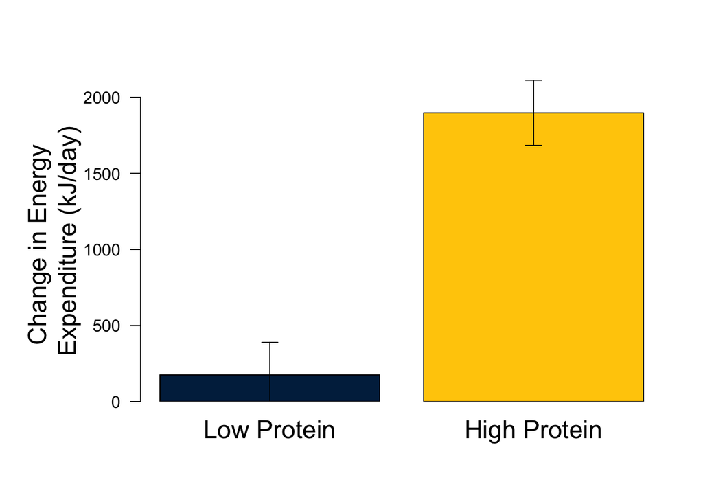

Effect of Diet on Energy Expenditure After 8 Weeks of Overfeeding

The data from the table was re-entered as Bray JAMA 2012 Table.csv.

## Bray et al Follow-Up Study

In a follow up study, Bray et al. (2015) looked at the energy expenditure in a tissue specific manner via DEXA scans.

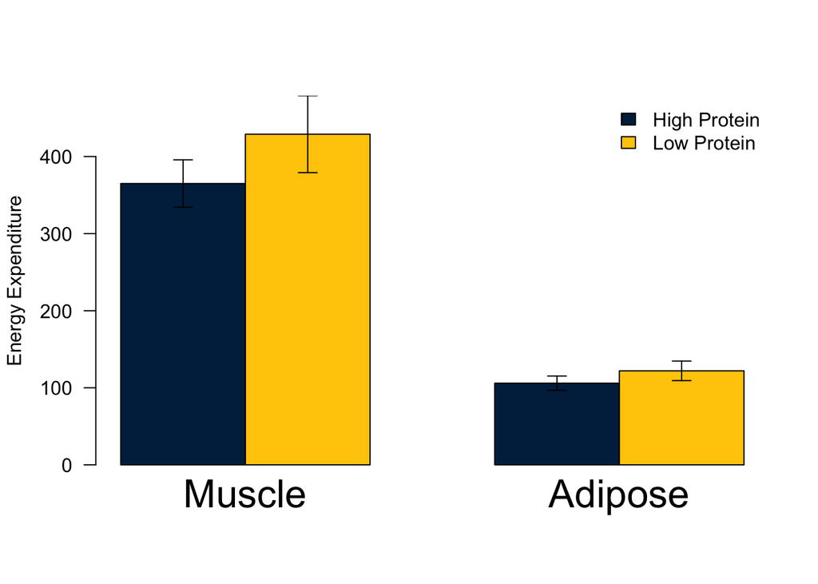

Effect of Diet on Energy Expenditure in Adipose and Muscle

## Ravussin AJCN

Ravussin *et al*, Ravussin et al. (1982) looked at the energy expenditure in men and women of differing obesity status.

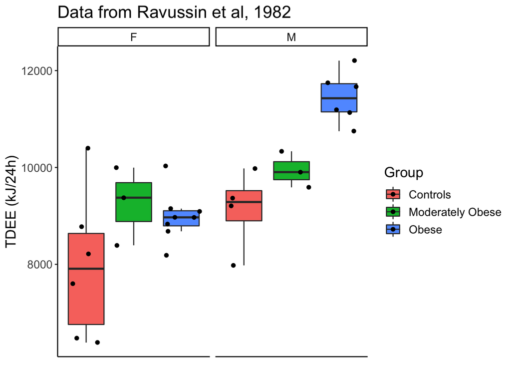

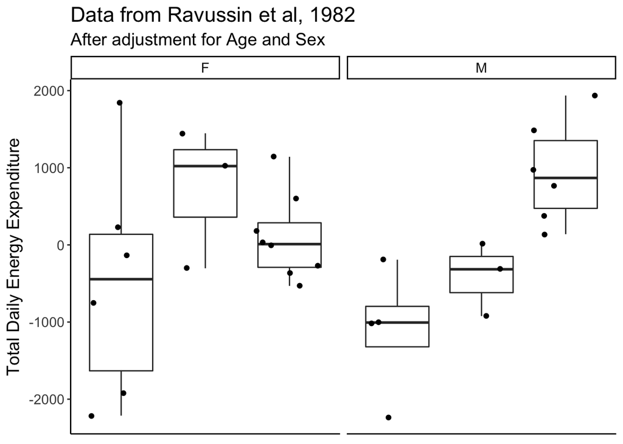

# Seyssel et al 2014

|  | ID | adj.P.Val | P.Value | t | B | logFC | Gene.symbol | Gene.title |
| --- | --- | --- | --- | --- | --- | --- | --- | --- |
| 225239_at | 225239_at | 0.113 | 0 | -6.33 | 3.55 | -0.546 | MIR612///NEAT1 | microRNA 612///nuclear paraspeckle assembly transcript 1 (non-protein coding) |
| 212527_at | 212527_at | 0.113 | 0 | 6.33 | 3.54 | 0.361 | DESI1 | desumoylating isopeptidase 1 |
| 228542_at | 228542_at | 0.173 | 0 | 5.80 | 2.70 | 0.332 | MRS2 | MRS2, magnesium transporter |
| 201563_at | 201563_at | 0.173 | 0 | 5.67 | 2.49 | 0.308 | SORD | sorbitol dehydrogenase |
| 236515_at | 236515_at | 0.173 | 0 | 5.64 | 2.45 | 0.250 |  |  |
| 238714_at | 238714_at | 0.173 | 0 | -5.55 | 2.29 | -0.290 |  |  |
| 223608_at | 223608_at | 0.173 | 0 | -5.38 | 2.01 | -0.293 | EFCAB2 | EF-hand calcium binding domain 2 |
| 211561_x_at | 211561_x_at | 0.173 | 0 | 5.28 | 1.83 | 0.223 | MAPK14 | mitogen-activated protein kinase 14 |
| 223212_at | 223212_at | 0.173 | 0 | 5.28 | 1.82 | 0.232 | ZDHHC16 | zinc finger DHHC-type containing 16 |
| 1558048_x_at | 1558048_x_at | 0.173 | 0 | -5.24 | 1.76 | -0.354 |  |  |
| 211572_s_at | 211572_s_at | 0.173 | 0 | 5.22 | 1.73 | 0.254 | SLC23A2 | solute carrier family 23 member 2 |
| 1558512_at | 1558512_at | 0.173 | 0 | -5.17 | 1.64 | -0.257 | LOC105369477 | uncharacterized LOC105369477 |
| 223479_s_at | 223479_s_at | 0.173 | 0 | 5.17 | 1.64 | 0.232 | CHCHD5 | coiled-coil-helix-coiled-coil-helix domain containing 5 |
| 204554_at | 204554_at | 0.173 | 0 | -5.16 | 1.62 | -0.285 | PPP1R3D | protein phosphatase 1 regulatory subunit 3D |
| 232046_at | 232046_at | 0.173 | 0 | -5.14 | 1.59 | -0.238 | KIAA1217 | KIAA1217 |
| 236019_at | 236019_at | 0.173 | 0 | -5.11 | 1.54 | -0.272 | RAB12 | RAB12, member RAS oncogene family |
| 234989_at | 234989_at | 0.173 | 0 | -5.11 | 1.53 | -0.424 | MIR612///NEAT1 | microRNA 612///nuclear paraspeckle assembly transcript 1 (non-protein coding) |
| 205694_at | 205694_at | 0.173 | 0 | 5.10 | 1.52 | 0.482 | TYRP1 | tyrosinase related protein 1 |
| 222801_s_at | 222801_s_at | 0.173 | 0 | 5.09 | 1.51 | 0.213 | STAG3L4 | stromal antigen 3-like 4 (pseudogene) |
| 227062_at | 227062_at | 0.173 | 0 | -5.07 | 1.46 | -0.426 | MIR612///NEAT1 | microRNA 612///nuclear paraspeckle assembly transcript 1 (non-protein coding) |
| 235921_at | 235921_at | 0.173 | 0 | 5.04 | 1.41 | 0.284 | LOC102723721 | uncharacterized LOC102723721 |
| 226073_at | 226073_at | 0.173 | 0 | 5.04 | 1.40 | 0.253 | TMEM218 | transmembrane protein 218 |
| 209094_at | 209094_at | 0.176 | 0 | -5.00 | 1.33 | -0.206 | DDAH1 | dimethylarginine dimethylaminohydrolase 1 |
| 202399_s_at | 202399_s_at | 0.176 | 0 | 4.99 | 1.32 | 0.203 | C15orf38-AP3S2///AP3S2 | C15orf38-AP3S2 readthrough///adaptor related protein complex 3 sigma 2 subunit |
| 201170_s_at | 201170_s_at | 0.186 | 0 | -4.95 | 1.25 | -0.392 | BHLHE40 | basic helix-loop-helix family member e40 |

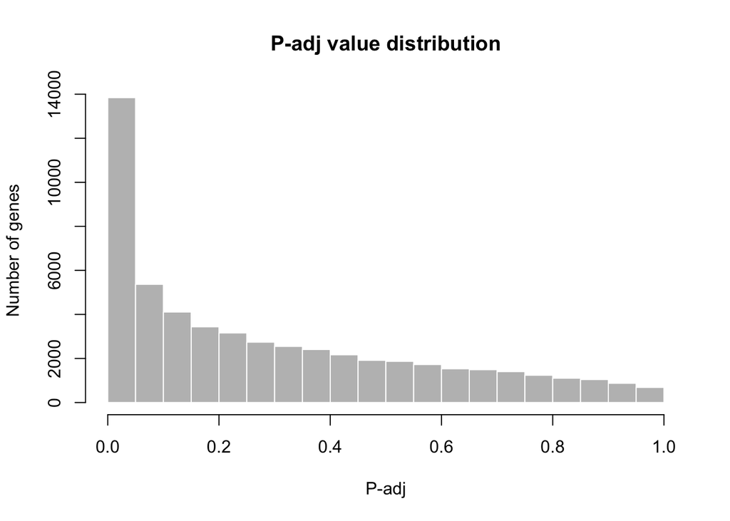

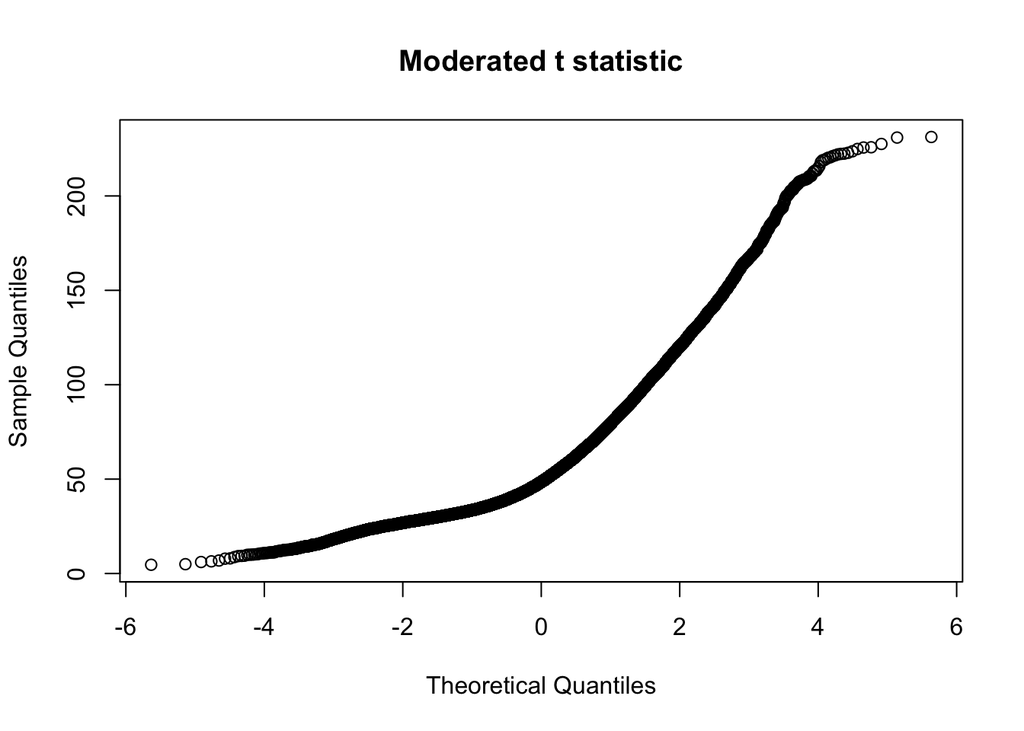

```
##  [1] "(Intercept)"  "subject3"     "subject5"     "subject6"     "subject8"
##  [6] "subject9"     "subject11"    "subject16"    "subject17"    "subject18"
## [11] "subject19"    "subject20"    "groupOverfed"
```

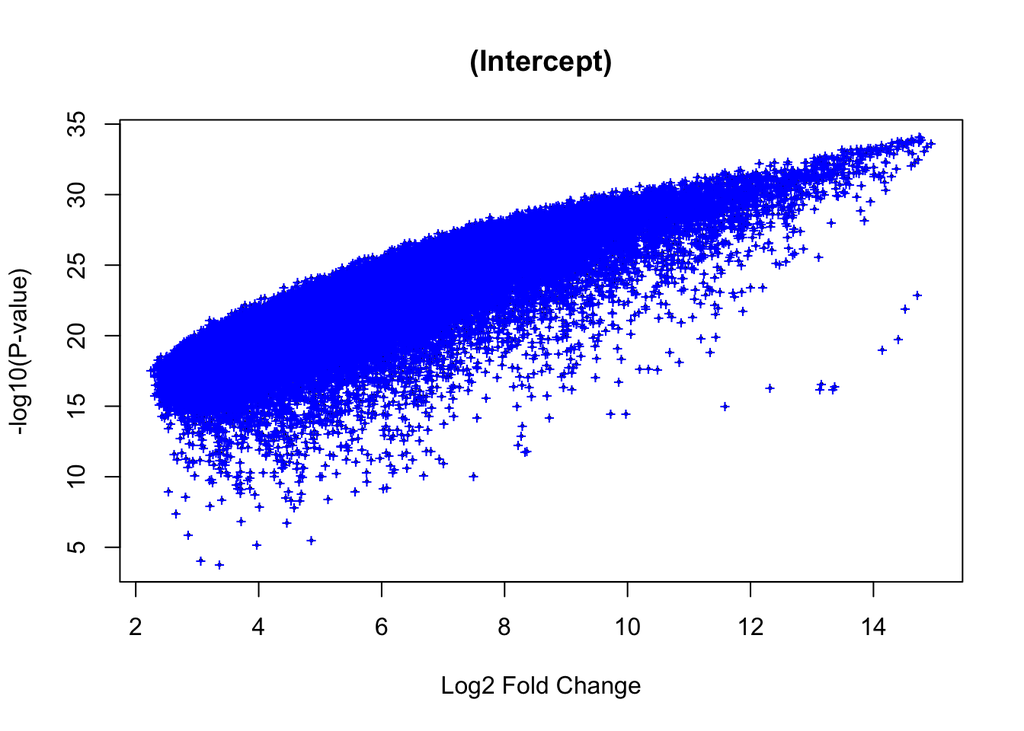

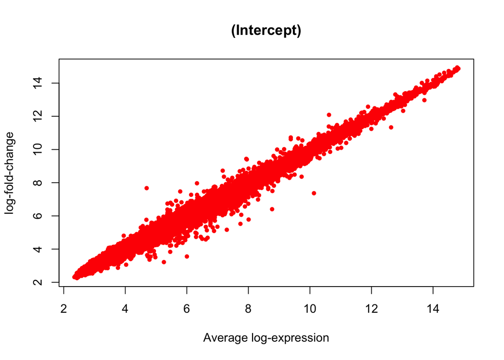

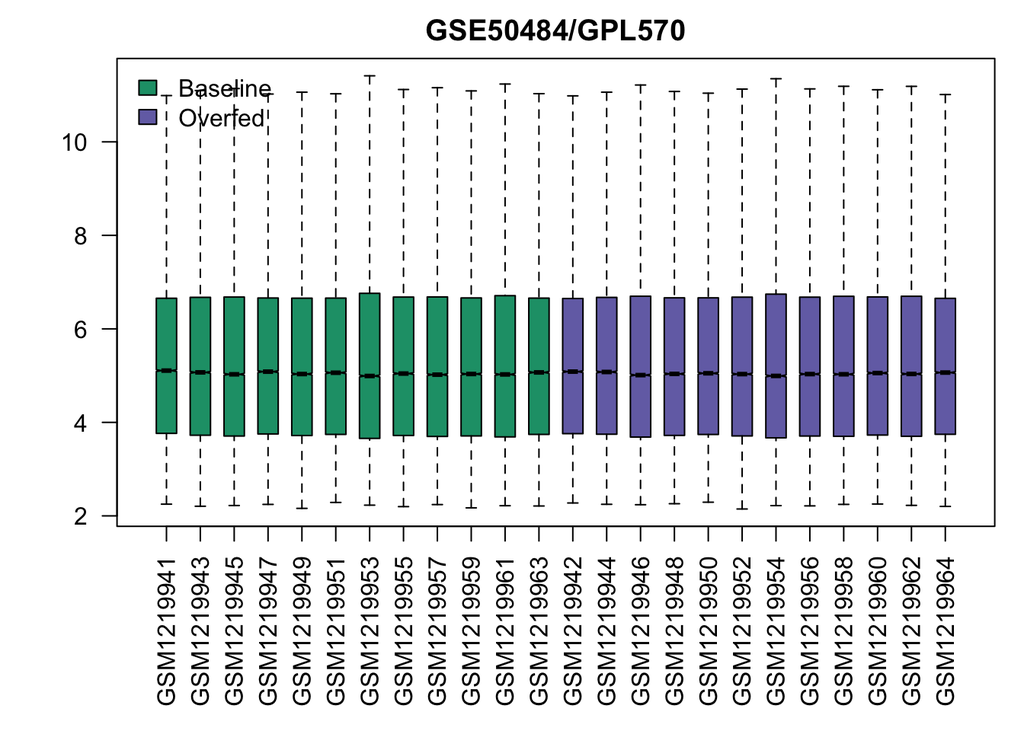

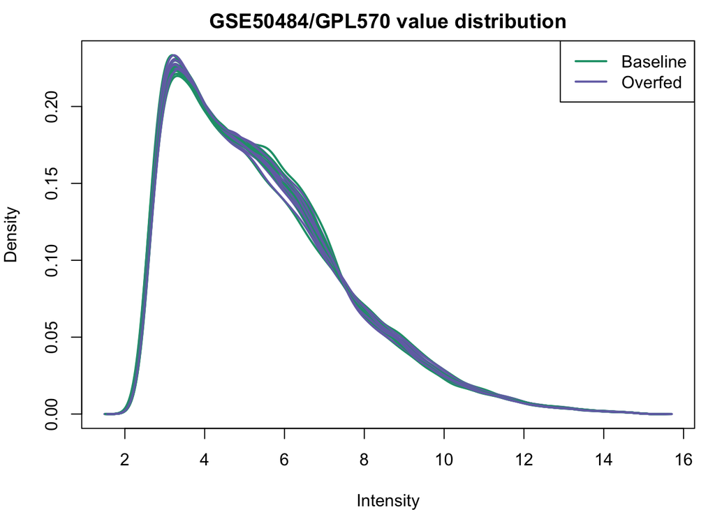

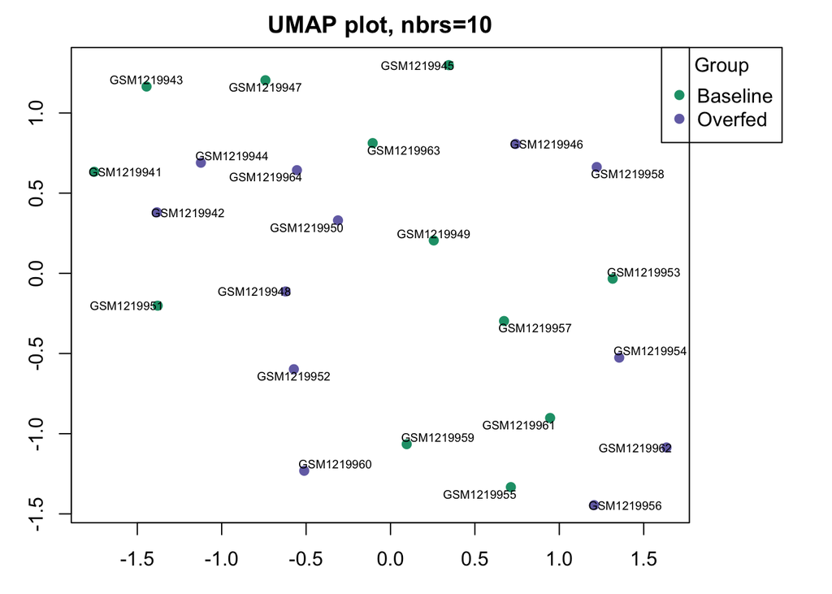

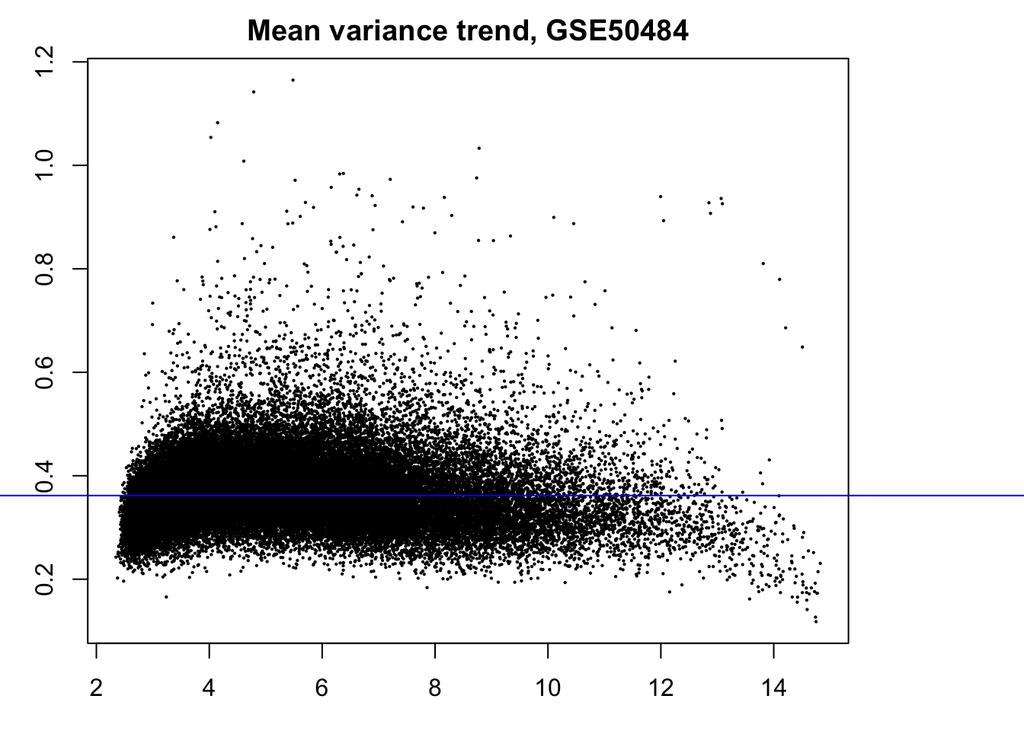

[1] G. A. Bray, L. M. Redman, L. de Jonge, et al. “Effect of protein overfeeding on energy expenditure measured in a metabolic chamber”. In: *The American Journal of Clinical Nutrition* 101.3 (Jan. 2015), pp. 496-505. DOI: 10.3945/ajcn.114.091769. <URL: https://doi.org/10.3945/ajcn.114.091769>.

[2] G. A. Bray, S. R. Smith, L. de Jonge, et al. “Effect of Dietary Protein Content on Weight Gain, Energy Expenditure, and Body Composition During Overeating”. In: *JAMA* 307.1 (Jan. 2012), p. 47. DOI: 10.1001/jama.2011.1918. <URL: https://doi.org/10.1001/jama.2011.1918>.

[3] C. B. Ebbeling, J. F. Swain, H. A. Feldman, et al. “Effects of Dietary Composition on Energy Expenditure During Weight-Loss Maintenance”. In: *JAMA* 307.24 (Jun. 2012). ISSN: 0098-7484. DOI: 10.1001/jama.2012.6607. <URL: http://dx.doi.org/10.1001/jama.2012.6607>.

[4] E. Ravussin, B. Burnand, Y. Schutz, et al. “Twenty-four-hour energy expenditure and resting metabolic rate in obese, moderately obese, and control subjects”. In: *The American Journal of Clinical Nutrition* 35.3 (Mar. 1982), pp. 566-573. DOI: 10.1093/ajcn/35.3.566. <URL: https://doi.org/10.1093/ajcn/35.3.566>.

# Session Information

R version 4.0.2 (2020-06-22) Platform: x86_64-apple-darwin17.0 (64-bit) Running under: macOS 10.16

Matrix products: default BLAS: /Library/Frameworks/R.framework/Versions/4.0/Resources/lib/libRblas.dylib LAPACK: /Library/Frameworks/R.framework/Versions/4.0/Resources/lib/libRlapack.dylib

locale: [1] en_US.UTF-8/en_US.UTF-8/en_US.UTF-8/C/en_US.UTF-8/en_US.UTF-8

attached base packages: [1] parallel stats graphics grDevices utils datasets methods  
[8] base

other attached packages: [1] maptools_1.0-2 sp_1.4-4 umap_0.2.7.0  
[4] limma_3.44.3 GEOquery_2.56.0 Biobase_2.48.0  
[7] BiocGenerics_0.34.0 ggplot2_3.3.3 knitcitations_1.0.12 [10] dplyr_1.0.2 tidyr_1.1.2 knitr_1.30

loaded via a namespace (and not attached): [1] reticulate_1.18 tidyselect_1.1.0 xfun_0.19 purrr_0.3.4  
[5] lattice_0.20-41 colorspace_2.0-0 vctrs_0.3.6 generics_0.1.0  
[9] htmltools_0.5.0 yaml_2.2.1 rlang_0.4.10 pillar_1.4.7  
[13] foreign_0.8-81 glue_1.4.2 withr_2.3.0 lifecycle_0.2.0  
[17] plyr_1.8.6 stringr_1.4.0 munsell_0.5.0 gtable_0.3.0  
[21] evaluate_0.14 labeling_0.4.2 curl_4.3 fansi_0.4.1  
[25] highr_0.8 Rcpp_1.0.5 readr_1.4.0 openssl_1.4.3  
[29] scales_1.1.1 jsonlite_1.7.2 mime_0.9 farver_2.0.3  
[33] RSpectra_0.16-0 hms_0.5.3 askpass_1.1 digest_0.6.27  
[37] stringi_1.5.3 grid_4.0.2 bibtex_0.4.2.3 cli_2.2.0  
[41] tools_4.0.2 magrittr_2.0.1 tibble_3.0.4 RefManageR_1.3.0 [45] crayon_1.3.4 pkgconfig_2.0.3 ellipsis_0.3.1 Matrix_1.3-0  
[49] xml2_1.3.2 lubridate_1.7.9.2 rstudioapi_0.13 assertthat_0.2.1 [53] rmarkdown_2.6 httr_1.4.2 R6_2.5.0 compiler_4.0.2

# Bibliography

Bray, George A, Leanne M Redman, Lilian de Jonge, Jeffrey Covington, Jennifer Rood, Courtney Brock, Susan Mancuso, Corby K Martin, and Steven R Smith. 2015. “Effect of Protein Overfeeding on Energy Expenditure Measured in a Metabolic Chamber.” *The American Journal of Clinical Nutrition* 101 (3). Oxford University Press (OUP): 496–505. https://doi.org/10.3945/ajcn.114.091769.

Bray, George A., Steven R. Smith, Lilian de Jonge, Hui Xie, Jennifer Rood, Corby K. Martin, Marlene Most, Courtney Brock, Susan Mancuso, and Leanne M. Redman. 2012. “Effect of Dietary Protein Content on Weight Gain, Energy Expenditure, and Body Composition During Overeating.” *JAMA* 307 (1). American Medical Association (AMA): 47. https://doi.org/10.1001/jama.2011.1918.

Ebbeling, Cara B., Janis F. Swain, Henry A. Feldman, William W. Wong, David L. Hachey, Erica Garcia-Lago, and David S. Ludwig. 2012. “Effects of Dietary Composition on Energy Expenditure During Weight-Loss Maintenance.” *JAMA* 307 (24). American Medical Association (AMA). https://doi.org/10.1001/jama.2012.6607.

Ravussin, E, B Burnand, Y Schutz, and E J’equier. 1982. “Twenty-Four-Hour Energy Expenditure and Resting Metabolic Rate in Obese, Moderately Obese, and Control Subjects.” *The American Journal of Clinical Nutrition* 35 (3). Oxford University Press (OUP): 566–73. https://doi.org/10.1093/ajcn/35.3.566.